# A contrived example to break diff-in-diffs

Andi Fugard

28 December 2024

Include packages:

```r
library(tidyverse)
library(did)
```

First setup the true scores for each individual:

```r
set.seed(42)
true_outcomes <- data.frame(id = 1:8000) |>
  mutate(true = rnorm(n(), 0, 1))
```

Look at a random sample:

```r
true_outcomes |>
  mutate(true = round(true, 2)) |>
  slice_sample(n = 10)
```

| id | true |
| --- | --- |
| 6691 | 0.79 |
| 4865 | -0.74 |
| 1748 | -0.77 |
| 4927 | 0.57 |
| 4177 | -1.09 |
| 6615 | -0.33 |
| 3509 | -0.39 |
| 4738 | 1.33 |
| 7700 | 0.82 |
| 6844 | 0.43 |

Now the measured outcomes, which are noisy version of the true score:

```r
gen_obs <- function(id, true, sd, n) {
  data.frame(time = 1:n) |>
    mutate(id = id, .before = time) |>
    mutate(true = true,
           y = true + rnorm(n, 0, sd))
}

sim_dat <- pmap_df(true_outcomes,
                   \(id, true) gen_obs(id = id, true = true, sd = 1, n = 4)) |>
  mutate(y = scale(y) |> as.numeric())
```

Look at a random sample:

```r
sim_dat |>
  mutate(true = round(true, 2),
         y = round(y, 2)) |>
  slice_sample(n = 10)
```

| id | time | true | y |
| --- | --- | --- | --- |
| 2855 | 3 | -0.20 | -0.84 |
| 2320 | 3 | 0.13 | 0.03 |
| 4198 | 3 | -0.69 | -1.03 |
| 1047 | 3 | -0.25 | -0.15 |
| 7009 | 1 | -2.21 | -1.70 |
| 4103 | 2 | 0.77 | 1.46 |
| 3938 | 2 | 1.30 | 2.10 |
| 6836 | 1 | 1.88 | 1.34 |
| 5571 | 3 | 0.64 | 1.35 |
| 3196 | 4 | -0.62 | -1.23 |

We have standardised y:

```r
mean(sim_dat$y) |> round(2)
```

```
## [1] 0
```

```r
sd(sim_dat$y) |> round(2)
```

```
## [1] 1
```

The correlations:

```r
sim_dat |>
  pivot_wider(names_from = time, values_from = y) |>
  select(-id) |>
  cor() |>
  round(1)
```

```
##      true   1   2   3   4
## true  1.0 0.7 0.7 0.7 0.7
## 1     0.7 1.0 0.5 0.5 0.5
## 2     0.7 0.5 1.0 0.5 0.5
## 3     0.7 0.5 0.5 1.0 0.5
## 4     0.7 0.5 0.5 0.5 1.0
```

Each measurement is correlated about .7 with the (unmeasurable) true score and the measurements are correlated around .5 with each other.

Now, select people for the intervention if their scores 1 SD below the population mean or less for periods prior to the intervention period.

```r
ids <- list()

ids[[3]] <- sim_dat |>
  filter(time %in% 1:2 & y < -1) |>
  pull(id) |>
  unique() |>
  sample(size = 500)

ids[[4]] <- sim_dat |>
  filter(time %in% 1:3 & y < -1) |>
  pull(id) |>
  setdiff(ids[[3]]) |>
  unique() |>
  sample(size = 500)

ids[[5]] <- setdiff(sim_dat$id, c(ids[[3]], ids[[4]])) |>
  sample(size = 500)
```

Build a dataset mapping ID to group. {did} treats group = 0 as never-treated.

```r
group_ids <- list(
  data.frame(id = ids[[3]], group = 3),
  data.frame(id = ids[[4]], group = 4),
  data.frame(id = ids[[5]], group = 0)) |>
  bind_rows()
stopifnot((group_ids |> duplicated() |> sum()) == 0)
```

Join into the main dataset and drop missings:

```r
sim_dat <- sim_dat |>
  left_join(group_ids) |>
  na.omit()
```

Here are the means by group:

```r
sim_dat |>
  group_by(group, time) |>
  summarise(mean_y = mean(y) |> round(1),
            n = n()) |>
  mutate(treat = time >= group & group != 0, .after = time)
```

| group | time | treat | mean_y | n |
| --- | --- | --- | --- | --- |
| 0 | 1 | FALSE | 0.1 | 500 |
| 0 | 2 | FALSE | 0.1 | 500 |
| 0 | 3 | FALSE | 0.1 | 500 |
| 0 | 4 | FALSE | 0.1 | 500 |
| 3 | 1 | FALSE | -1.0 | 500 |
| 3 | 2 | FALSE | -1.1 | 500 |
| 3 | 3 | TRUE | -0.7 | 500 |
| 3 | 4 | TRUE | -0.7 | 500 |
| 4 | 1 | FALSE | -0.8 | 500 |
| 4 | 2 | FALSE | -0.8 | 500 |

[output cut: 2 more lines]

A couple of plots:

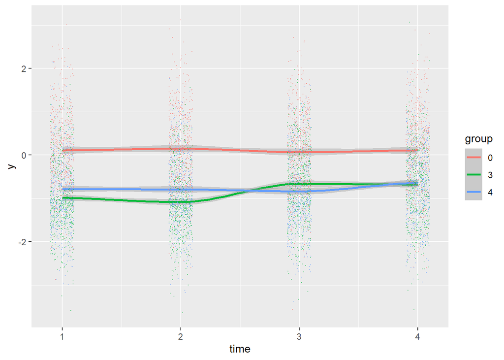

```r
curvy_plot <- sim_dat |>
  mutate(group = factor(group)) |>
  ggplot() +
  aes(x = time, y = y, colour = group) +
  geom_smooth(method = "loess", formula = y ~ x)
curvy_plot +
  geom_jitter(alpha = .5, width = .1, size = .1)
```

Zoom in and remove the points:

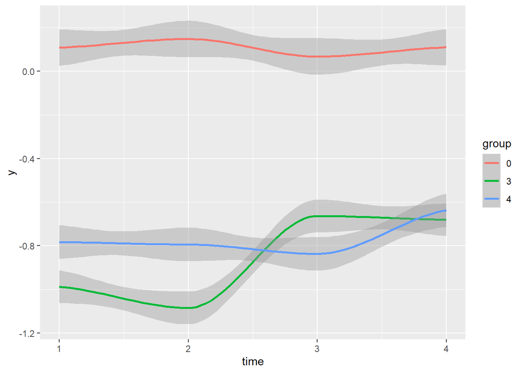

```r
curvy_plot
```

The never treated group (0) cruise along a little above the population mean (0 by design) with no apparent change. The means of group 3 and 4 are much lower (as expected, since we select them to be 1 SD below the mean or less), apparently increasing as the intervention is introduced.

Let’s see what {did} makes of this:

```r
did_mod <- att_gt(
  yname = "y",
  gname = "group",
  control_group = "notyettreated",
  idname = "id",
  tname = "time",
  data = sim_dat,
  est_method = "reg",
  base_period = "varying"
)
did_mod
```

```
##
## Call:
## att_gt(yname = "y", tname = "time", idname = "id", gname = "group",
##     data = sim_dat, control_group = "notyettreated", est_method = "reg",
##     base_period = "varying")
##
## Reference: Callaway, Brantly and Pedro H.C. Sant'Anna.  "Difference-in-Differences with Multiple Time Periods." Journal of Econometrics, Vol. 225, No. 2, pp. 200-230, 2021. <https://doi.org/10.1016/j.jeconom.2020.12.001>, <https://arxiv.org/abs/1803.09015>
##
## Group-Time Average Treatment Effects:
##  Group Time ATT(g,t) Std. Error [95% Simult.  Conf. Band]
##      3    2  -0.1112     0.0640       -0.2745      0.0521
##      3    3   0.4829     0.0637        0.3204      0.6454 *
##      3    4   0.4423     0.0655        0.2751      0.6095 *
##      4    2   0.0179     0.0619       -0.1402      0.1759
##      4    3   0.0368     0.0728       -0.1490      0.2226
##      4    4   0.1580     0.0638       -0.0048      0.3208
## ---
## Signif. codes: `*' confidence band does not cover 0
##
## P-value for pre-test of parallel trends assumption:  0.28651
## Control Group:  Not Yet Treated,  Anticipation Periods:  0
## Estimation Method:  Outcome Regression
```

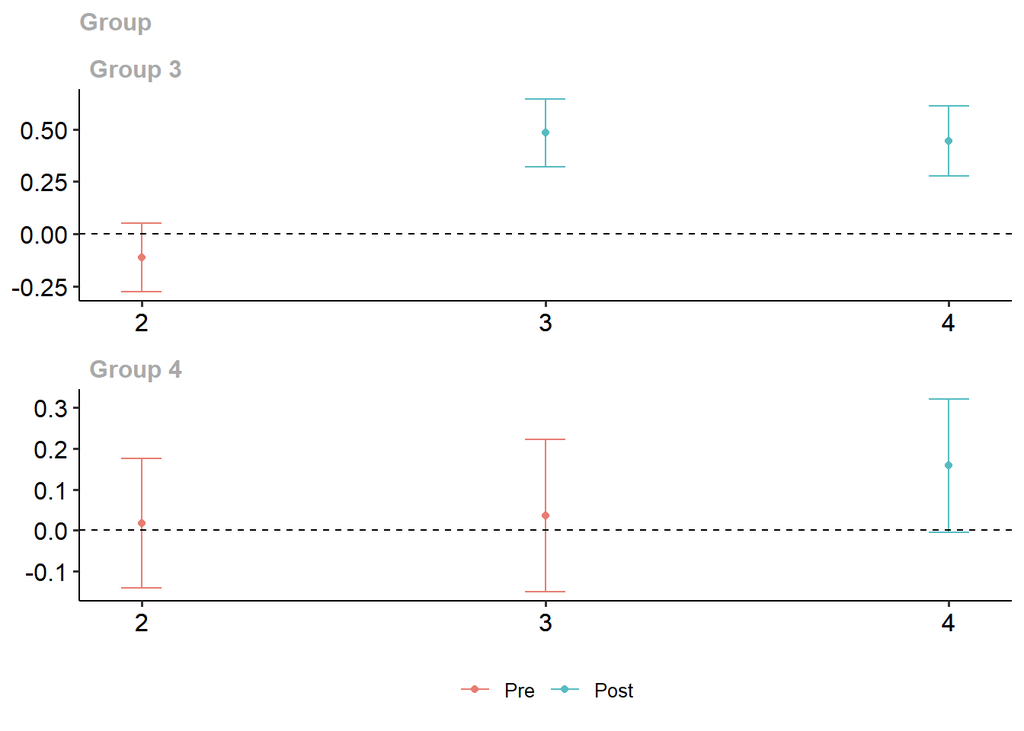

```r
did_mod |>
  ggdid()
```

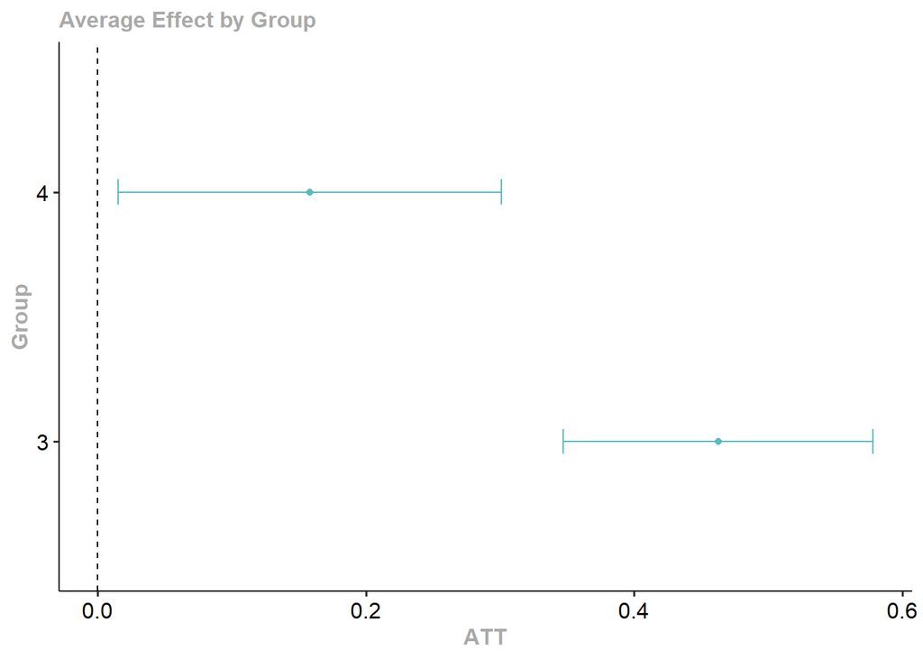

```r
aggte(did_mod, type = "group") |>
  ggdid()
```

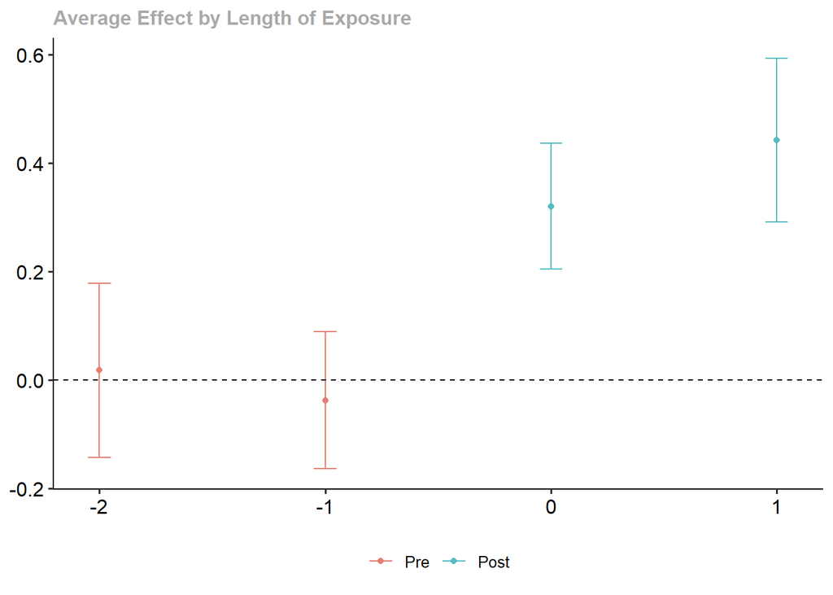

```r
aggte(did_mod, type = "dynamic") |>
  ggdid()
```

Would we conclude that the intervention was effective if we didn’t know how the data were generated…?

What happens if we remove the never-treated group?

```r
sim_dat_sometimes_treated <- sim_dat |>
  filter(group != 0)
```

```r
did_mod_2 <- att_gt(
  yname = "y",
  gname = "group",
  control_group = "notyettreated",
  idname = "id",
  tname = "time",
  data = sim_dat_sometimes_treated,
  est_method = "reg",
  base_period = "varying"
)

did_mod_2
```

```
##
## Call:
## att_gt(yname = "y", tname = "time", idname = "id", gname = "group",
##     data = sim_dat_sometimes_treated, control_group = "notyettreated",
##     est_method = "reg", base_period = "varying")
##
## Reference: Callaway, Brantly and Pedro H.C. Sant'Anna.  "Difference-in-Differences with Multiple Time Periods." Journal of Econometrics, Vol. 225, No. 2, pp. 200-230, 2021. <https://doi.org/10.1016/j.jeconom.2020.12.001>, <https://arxiv.org/abs/1803.09015>
##
## Group-Time Average Treatment Effects:
##  Group Time ATT(g,t) Std. Error [95% Simult.  Conf. Band]
##      3    2  -0.0861     0.0763       -0.2576      0.0854
##      3    3   0.4645     0.0685        0.3106      0.6184 *
## ---
## Signif. codes: `*' confidence band does not cover 0
##
## P-value for pre-test of parallel trends assumption:  0.26747
## Control Group:  Not Yet Treated,  Anticipation Periods:  0
## Estimation Method:  Outcome Regression
```

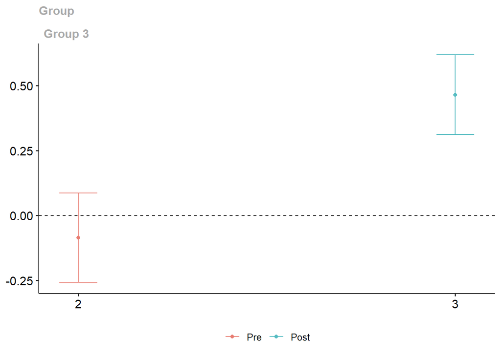

```r
did_mod_2 |>
  ggdid()
```